# MIDI-MT - Module for controlling the execution of user “Scripts”

MIDI-MT Documentation in English

## Module for controlling the execution of user scripts

- Assigning scripts to MIDI-MT
- Scenarios in the “Audio Mixer” and “MIDI Control” groups
- Scenarios in the “Smart Home Device Control” and “Lighting Control” groups
- Settings of the scenario management module
- Configuration file
- Brief information about the main characteristics of the ChaiScript language
  - ChaiScript - supported types
  - ChaiScript - documentation and examples
- ChaiScript - debugging with DebugView
- Debugging when writing your own scripts
- Specific MIDI-MT API objects in scripts

```
     The scripting core of MIDI-MT is ChaiScript
     ChaiScript is a typed declarative language with syntax similar to C++, TypeScript and JavaScript.
```

#### Assigning scripts to MIDI-MT

You can use your own scripts to automate management processes across different groups. Batch control via executable scripts can expand your capabilities, for example:

- application of a pre-planned level scheme on several regulators,
- solving problems of simultaneous, smooth adjustment of levels on many regulators,
- simultaneous switching on or off of multiple sources,
- various lighting effects and patterns applied at the touch of a button,
- execution of a sequence of commands for `Adobe` products..

The scripting core is `ChaiScript`, an open source scripting language created by Jason Turner.  
The syntax of `ChaiScript` scripts is almost identical to `JavaScript`, and in fact follows the `ECMASCRIPT` standard, with minor additions. Below are the main features of this scripting language.

#### “Audio Mixer” and “MIDI Control” groups

Scripts can be thought of as ‘macros’ when applied to the “**Audio Mixer**” group or the “**MIDI Control**” group to control `Adobe` products such as `Premiere Pro`, `After Effects`, `Audition` and so on. A sequential set of commands written in the script can be executed by pressing one button. This not only saves time, but also allows you to use fewer physical buttons while maintaining the same functionality.

#### Groups “Smart Home Device Control” and “Lighting Control”

Scripts can be used to create both “control scenarios” for the “**Smart Home**” group, and to create your own unique lighting effects and solutions for the “**Lighting Control**” and “**Smart Home**” groups.

### Settings of the “Script Management” module

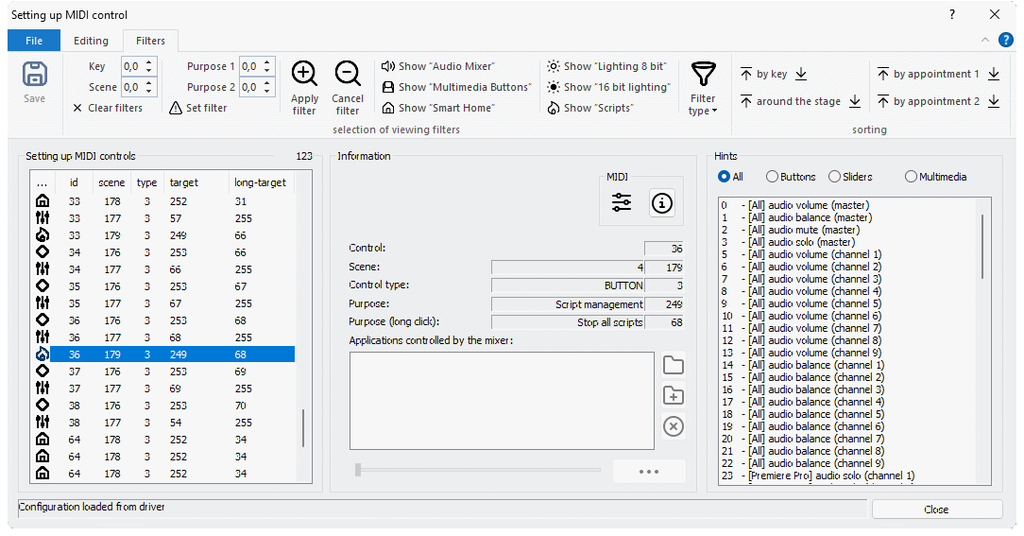

- The “**Available Scripts**” list displays all available scripts in the selected directory. Script files must have the extension `.mmts`. For each script file, its size and last modification time are displayed. Please note that the modification time is set to the current time when the program starts. These changes do not affect the actual files on the disk.
- Selecting “**Script Directory**” allows you to select the path where the scripts to be executed are located.
- The option “**Monitor changes in the script directory**” enables tracking of changes to script files in the selected directory. If one of the scripts is changed, added or deleted, the list of scripts is automatically reloaded.
- The “**Debug mode**” option allows you to redirect the output of the script from the log file to a specialized program, for example DebugView or [Visual Studio Code](https://github.com/microsoft/vscode).
- The options “**Don’t use … libraries**” allows you to disable libraries you don’t use.

The maximum number of called scripts in the configuration settings is limited to `27`.  
There is no limit on the simultaneous launch of scripts, but it also cannot exceed the value `27`.  
Calling the script again leads to its completion if it was running at that moment. Each script can only be active in one instance.

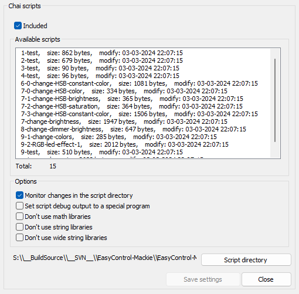

To develop and test scripts, the distribution kit includes the `MMTScriptTester.exe` utility.  
You can use it for debugging when writing your own scripts. The function of tracking changes in the script directory also works in `MMTScript Tester`; scripts are reloaded automatically if they change. If changes occur during the execution of any script, then the changes are postponed until the end of its execution.

#### Configuration file

The settings in the configuration file look like this:

```yaml
{
    ...
    "vmscript": {
        "enable": true,
        "watch": true,
        "debug": false,
        "stringlib": true,
        "wstringlib": true,
        "matchlib": true,
        "directory": "C:\MIDI-MT\scripts",
        "scripts": [
           ...
        ]
    },
    ...
}
```

#### Brief information about the main characteristics of the ChaiScript language

- Variables do not have a type until they are first assigned a value.
- Constructs like if, else, for and while only accept blocks enclosed in `{ ... };`.
- Increment and decrement operators, only before the `++value` variable.
- Keywords: `attr, auto, break, case, catch, class, continue, def, default, else, finally, for, global, if, return, switch, try, var, while`.
- Operators: `? || && | ^ & == != < <= > >= << >> + - * / % ++ -- ! ~`.
- Global IDs: `Nan, Infinity, false, true, __CLASS__, __FILE__ , __FUNC__, __LINE__`.
- Variables: `auto, var`.
- Functions: always start with the identifier `def` - `def my_function() { ... }`.
- Classes: yes, similar to `C++`, more details in the original documentation.
- Integer literals as in C++. Decimal binary, octal and hexadecimal integer literals are supported.
- Floating point numbers are like C++, but hexadecimal floating point literals are not supported.
- String literals are normally enclosed in double quotes, and they can also contain interpolations, which are enclosed in `${ ... }`.
- Comments: `//... /* ... */ #`.
- Specific MIDI-MT API objects in scripts.

###### supported types:

- **Boolean**: `bool`.
- **Integers**: `int, long, unsigned_int, unsigned_long, long_long, unsigned_long_long, size_t, int8_t, int16_t, int32_t, int64_t, uint8_t, uint16_t, uint32_t, uint64_t`.
- **Floating points**: `double, long_double, float`.
- **Characters**: `char, wchar_t, char16_t, char32_t`.
- **Strings**: `string` (`C++ std::string`).
- **Aggregates**: `Vector, Map, Pair`.
- **Async**: `promise, future`.

#### DebugView

`DebugView` is an application that allows you to monitor debug output on your local system.  
It can display application debug output and also does not require applications to be modified to use the non-standard debug output API.  
`DebugView` intercepts and displays debug output. Author Mark Russinovich, [sysinternals](https://learn.microsoft.com/en-us/sysinternals/downloads/debugview).

#### ChaiScript documentation and examples

1. Find out more in [documentation and examples](https://chaiscript.com/examples.html#ChaiScript_Language_Examples) on the `ChaiScript` website.
2. View more [code examples](https://github.com/ChaiScript/ChaiScript/tree/master/unittests) `ChaiScript`.
3. `ChaiScript` [language reference](https://github.com/ChaiScript/ChaiScript/blob/develop/cheatsheet.md#language-reference).
4. Getting started with `ChaiScript`:
   - [PDF](https://github.com/ClaudiaCoord/MIDI-EasyControl-to-Mackie-translator-for-Premiere-Pro/tree/main/docs/API/script/Chaiscript-Overview-and-Tutorial-EN.pdf) | [site](https://drolliblog.wordpress.com/2017/12/22/chaiscript-overview-and-tutorial/) part 1 - Review and Tutorials,
   - [PDF](https://github.com/ClaudiaCoord/MIDI-EasyControl-to-Mackie-translator-for-Premiere-Pro/tree/main/docs/API/script/Chaiscript-Overview-and-Tutorial-Additional-EN.pdf) | [site](https://drolliblog.wordpress.com/2020/08/04/chaiscript-additional-topics/) part 2 - Overview and additional tutorials,
   - [site](https://codedocs.xyz/ChaiScript/ChaiScript/LangGettingStarted.html) part 3 - How to start.
5. Specific MIDI-MT API objects in scripts.
6. Example [MIDI-MT API](https://github.com/ClaudiaCoord/MIDI-EasyControl-to-Mackie-translator-for-Premiere-Pro/tree/main/docs/API/script/example/example-api.mmts).
7. Examples of **RGB LED** controls:
   - [example of RGB-led effect](https://github.com/ClaudiaCoord/MIDI-EasyControl-to-Mackie-translator-for-Premiere-Pro/tree/main/docs/API/script/example/example-RGB-led-effect-1.mmts),
   - [example fixed color change](https://github.com/ClaudiaCoord/MIDI-EasyControl-to-Mackie-translator-for-Premiere-Pro/tree/main/docs/API/script/example/example-change-HSV-color-constant.mmts),
   - [example color change](https://github.com/ClaudiaCoord/MIDI-EasyControl-to-Mackie-translator-for-Premiere-Pro/tree/main/docs/API/script/example/example-change-HSV-color.mmts),
   - [example brightness change](https://github.com/ClaudiaCoord/MIDI-EasyControl-to-Mackie-translator-for-Premiere-Pro/tree/main/docs/API/script/example/example-change-HSV-brightness.mmts),
   - [example saturation change](https://github.com/ClaudiaCoord/MIDI-EasyControl-to-Mackie-translator-for-Premiere-Pro/tree/main/docs/API/script/example/example-change-HSV-saturation.mmts).
8. Other examples:
   - [example of using a “macro”](https://github.com/ClaudiaCoord/MIDI-EasyControl-to-Mackie-translator-for-Premiere-Pro/tree/main/docs/API/script/example/example-macro-using.mmts),
   - [example getting a list of controls from the current configuration](https://github.com/ClaudiaCoord/MIDI-EasyControl-to-Mackie-translator-for-Premiere-Pro/tree/main/docs/API/script/example/example-units-list.mmts).
9. Useful additions:
   - [ChaiScript language support for Notepad++](https://github.com/ChaiScript/npp-chaiscript),
   - [VsCode ChaiScript syntax](https://github.com/codehz/vscode-chaiscript-syntax),
   - [TypeScript to Chaiscript transpiler](https://github.com/Alia5/TSChai),
   - Download `DebugView` [x64](https://live.sysinternals.com/dbgview64.exe) | [x32](https://live.sysinternals.com/Dbgview.exe) | [ZIP](https://download.sysinternals.com/files/DebugView.zip) from [sysinternals](https://learn.microsoft.com/en-us/sysinternals/).